# Exercise_MLPR2023_Part3_73e94c3f-a547-11ed-a26a-38fc986e2b5b

This is the template for the image recognition exercise.  
Some **general instructions**, read these carefully:

- The final assignment is returned as a clear and understandable *report*
  - define shortly the concepts and explain the phases you use
  - use the Markdown feature of the notebook for larger explanations
- return your output as a *working* Jupyter notebook
- name your file as Exercise_MLPR2023_Partx_uuid.jpynb
  - use the uuid code determined below
  - use this same code for each part of the assignment
- write easily readable code with comments
  - if you exploit code from web, provide a reference
- it is ok to discuss with a friend about the assignment. But it is not ok to copy someone's work. Everyone should submit their own implementation
  - in case of identical submissions, both submissions are failed

**Deadlines:**

- Part 1: Mon 6.2 at 23:59**
- Part 2: Mon 20.2 at 23:59**
- Part 3: Mon 6.3 at 23:59**

**No extensions for the deadlines**

- after each deadline, example results are given, and it is not possible to submit anymore

**If you encounter problems, Google first and if you can’t find an answer, ask for help**

- Moodle area for questions
- pekavir@utu.fi
- teacher available for questions on Mondays 30.1, 13.2 (after lecture) and Thursday 2.3 (at lecture)

**Grading**

The exercise covers a part of the grading in this course. The course exam has 5 questions, 6 points of each. Exercise gives 6 points, i.e. the total score is 36 points.

From the template below, you can see how many exercise points can be acquired from each task. Exam points are given according to the table below:

7 exercise points: 1 exam point  
8 exercise points: 2 exam points  
9 exercise points: 3 exam points  
10 exercise points: 4 exam points  
11 exercise points: 5 exam points  
12 exercise points: 6 exam points  
To pass the exercise, you need at least 7 exercise points, and at least 1 exercise point from each Part.

Each student will grade one submission from a peer and their own submission. After each Part deadline, example results are given. Study them carefully and perform the grading according to the given instructions. Mean value from the peer grading and self-grading is used for the final points.

```python
import uuid
# Run this cell only once and save the code. Use the same id code for each Part.
# Printing random id using uuid1()
print ("The id code is: ",end="")
print ('73e94c3f-a547-11ed-a26a-38fc986e2b5b')
```

```
The id code is: 73e94c3f-a547-11ed-a26a-38fc986e2b5b
```

# Introduction (1 p)

Write an introductory chapter for your report

- Explain what is the purpose of this task? - Describe, what kind of data were used? Where did it originate? Give correct reference. - Which methods did you use? - Describe shortly the results

# Part 2

Data exploration and model selection

# Part 3

## Performance estimation (2 p)

Use the previously gathered data (again, use the standardized features).  
Estimate the performance of each model using nested cross validation. Use 10-fold cross validation for outer and  
5-fold repeated cross validation with 3 repetitions for inner loop.  
Select the best model in the inner loop using the hyperparameter combinations and ranges defined in the Part 2.  
For each model, calculate the accuracy and the confusion matrix.  
Which hyperparameter/hyperparameter combination is most often chosen as the best one for each classifier?

## Discussion (2 p)

Discuss you results

- Which model performs the best? Why?
- Ponder the limitations and generalization of the models. How well will the classifiers perform for data outside this data set?
- Compare your results with the original article. Are they comparable?
- Ponder applications for these type of models (classifying rice or other plant species), who could benefit from them? Ponder also what would be interesting to study more on this area?
- What did you learn? What was difficult? Could you improve your own working process in some way?

# Imports

```python
import numpy as np
import pandas as pd
from sklearn.preprocessing import StandardScaler
from matplotlib import pyplot as plt
from tqdm import tqdm
from sklearn.neighbors import KNeighborsClassifier
from sklearn.model_selection import RepeatedKFold
from sklearn.ensemble import RandomForestClassifier
from sklearn.neural_network import MLPClassifier
from sklearn.model_selection import GridSearchCV
from sklearn.model_selection import KFold
from sklearn.metrics import accuracy_score
from sklearn import metrics
```

# Import and standardize data

```python
# read data
training_data = pd.read_csv('../training_data/training_data.csv', index_col = [0])

# display firs five rows
training_data.head()
```

|  | rice_type | path | r_mean | g_mean | b_mean | r_variance | g_variance | b_variance | r_skewness | g_skewness | ... | b_kurtosis | r_entropy | g_entropy | b_entropy | major_axis_length (px) | minor_axis_lenth (px) | contour_area (px) | contour_perimeter (px) | roundness | aspect_ratio |
| --- | --- | --- | --- | --- | --- | --- | --- | --- | --- | --- | --- | --- | --- | --- | --- | --- | --- | --- | --- | --- | --- |
| 0 | arborio | ../data/Arborio\Arborio (9204).jpg | 222.522289 | 222.462998 | 224.158894 | 414.157721 | 420.233364 | 331.755208 | -1.451926 | -1.451582 | ... | 3.853837 | 6.031748 | 6.041130 | 5.840202 | 129.655731 | 66.700142 | 6648.0 | 343.220343 | 0.709177 | 1.943860 |
| 1 | arborio | ../data/Arborio\Arborio (95).jpg | 225.105370 | 225.438161 | 231.659615 | 441.078683 | 460.979968 | 397.579497 | -1.039958 | -0.999778 | ... | 2.295804 | 6.098831 | 6.128041 | 5.903111 | 135.751190 | 69.416695 | 7221.0 | 357.019333 | 0.711908 | 1.955599 |
| 2 | arborio | ../data/Arborio\Arborio (6523).jpg | 207.078867 | 208.550371 | 218.762061 | 317.646307 | 338.739471 | 344.251594 | -0.909045 | -0.852550 | ... | 1.606971 | 5.986432 | 6.035016 | 6.021399 | 142.041885 | 73.650620 | 8065.5 | 378.433546 | 0.707721 | 1.928591 |
| 3 | arborio | ../data/Arborio\Arborio (7523).jpg | 196.267586 | 195.825107 | 205.800233 | 207.988053 | 209.938308 | 231.463681 | -1.117349 | -1.113135 | ... | 2.283707 | 5.726940 | 5.732542 | 5.769262 | 112.533409 | 57.882843 | 5013.5 | 295.722870 | 0.720412 | 1.944158 |
| 4 | arborio | ../data/Arborio\Arborio (11106).jpg | 200.921386 | 200.854356 | 203.404185 | 296.996302 | 299.498530 | 290.685397 | -0.693292 | -0.694011 | ... | 0.476972 | 5.963724 | 5.970757 | 5.946620 | 144.727615 | 74.547760 | 8303.0 | 377.102593 | 0.733712 | 1.941408 |

5 rows × 23 columns

```python
# a dataset with only the features
features = training_data.copy().drop(['rice_type', 'path'], axis=1)

#separate feature column names
cols = features.columns

# z-score scaleign
scaler = StandardScaler()
scale = scaler.fit_transform(features)

#back to dataframe
features = pd.DataFrame(scale)
features.columns = cols

#display first five rows
display(features.head())
```

|  | r_mean | g_mean | b_mean | r_variance | g_variance | b_variance | r_skewness | g_skewness | b_skewness | r_kurtosis | ... | b_kurtosis | r_entropy | g_entropy | b_entropy | major_axis_length (px) | minor_axis_lenth (px) | contour_area (px) | contour_perimeter (px) | roundness | aspect_ratio |
| --- | --- | --- | --- | --- | --- | --- | --- | --- | --- | --- | --- | --- | --- | --- | --- | --- | --- | --- | --- | --- | --- |
| 0 | 0.903478 | 0.468699 | -0.376299 | 1.609257 | 1.590499 | 1.133324 | -0.398200 | -0.129804 | 0.432525 | -0.558665 | ... | -0.788546 | 1.011422 | 0.943312 | 0.930546 | -1.155969 | 0.976376 | -0.261640 | -0.911635 | 1.189391 | -1.208987 |
| 1 | 1.193838 | 0.767847 | 0.272219 | 1.901135 | 2.028030 | 1.961155 | 0.185925 | 0.391209 | 0.884403 | -0.844676 | ... | -1.019225 | 1.205410 | 1.158406 | 1.051936 | -0.982381 | 1.214996 | 0.150479 | -0.665492 | 1.213981 | -1.198084 |
| 2 | -0.832487 | -0.930193 | -0.842913 | 0.562879 | 0.715431 | 1.290483 | 0.371545 | 0.560991 | 1.126394 | -0.883037 | ... | -1.121212 | 0.880376 | 0.928180 | 1.280185 | -0.803233 | 1.586901 | 0.757869 | -0.283511 | 1.176273 | -1.223169 |
| 3 | -2.047763 | -2.209699 | -1.963602 | -0.626038 | -0.667616 | -0.127980 | 0.076194 | 0.260488 | 0.937813 | -0.600138 | ... | -1.021016 | 0.129980 | 0.179593 | 0.793663 | -1.643583 | 0.201871 | -1.437223 | -1.758882 | 1.290571 | -1.208710 |
| 4 | -1.524638 | -1.704015 | -2.170766 | 0.338991 | 0.294068 | 0.616815 | 0.677459 | 0.743815 | 1.406361 | -1.095999 | ... | -1.288518 | 0.814711 | 0.769146 | 1.135892 | -0.726748 | 1.665706 | 0.928686 | -0.307252 | 1.410350 | -1.211264 |

5 rows × 21 columns

```python
labels = training_data['rice_type']
labels
```

```
0      arborio
1      arborio
2      arborio
3      arborio
4      arborio
        ...
295    jasmine
296    jasmine
297    jasmine
298    jasmine
299    jasmine
Name: rice_type, Length: 300, dtype: object
```

# Performance estimation

Estimate the performance of each model using nested cross validation. Use 10-fold cross validation for outer and 5-fold repeated cross validation with 3 repetitions for inner loop.  
Select the best model in the inner loop using the hyperparameter combinations and ranges defined in the Part 2. For each model, calculate the accuracy and the confusion matrix.  
Which hyperparameter/hyperparameter combination is most often chosen as the best one for each classifier?

```python
# initialize cross-validation methods
cv_inner = RepeatedKFold(n_splits=5, n_repeats=3, random_state=42)
cv_outer = KFold(n_splits=10, shuffle=True, random_state=1)
```

## KNN

```python
# parameter space
parameters={'n_neighbors': range(1,30)}
```

```python
def KNNnestedCrossValidation():
    # initialize arrays to store calculated values
    best_params = []
    accuracy_scores = []
    confusion_matrices = []

    #loop through the splits made by the outer cross validation method
    for train_index, test_index in tqdm(cv_outer.split(features), total=10):

        # make data frames based on split indexes
        train_features, test_features = features.iloc[train_index], features.iloc[test_index]
        train_labels, test_labels = labels.iloc[train_index], labels.iloc[test_index]


        knn_model = KNeighborsClassifier()# initialize model
        knn_cv = GridSearchCV(knn_model, parameters, cv=cv_inner, return_train_score=False) # cross validation
        fit = knn_cv.fit(train_features, train_labels) #fit with training data

        # get best values and add to array
        best_params.append(knn_cv.best_params_['n_neighbors']) # get best parametes
        best_model = fit.best_estimator_ # fit model with best parameters
        predictions = best_model.predict(test_features) # make prediction on the best model
        accuracy_scores.append(accuracy_score(test_labels, predictions)) # accuracy score on the best model
        confusion_matrices.append(metrics.confusion_matrix(test_labels, predictions, labels=best_model.classes_)) #confusion martrix on the best model

    return best_params, accuracy_scores, confusion_matrices, best_model.classes_
```

```python
best_params, accuracy_scores, confusion_matrices, disp_labels = KNNnestedCrossValidation()
```

```
Best value for k for each fold:  [3, 1, 1, 1, 1, 1, 1, 1, 1, 1]
Accuracy scores for each fold:  [0.9666666666666667, 1.0, 0.9333333333333333, 0.9666666666666667, 1.0, 1.0, 1.0, 1.0, 1.0, 1.0]
```

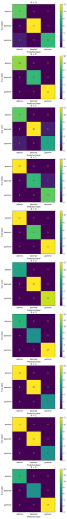

```python
print('Best value for k for each fold: ', best_params) # print best parameters of each outer fold
print('Accuracy scores for each fold: ' , accuracy_scores) # print best models accuracy score of each outer fold

# print confusion matrixis on each folds best model
fig, axs = plt.subplots(10, figsize=(10, 50))

for x in range(10):
    cmd = metrics.ConfusionMatrixDisplay(confusion_matrix = confusion_matrices[x], display_labels = disp_labels)
    cmd.plot(ax=axs[x])
    title = 'k = ' + str(best_params[x])
    axs[x].title.set_text(title)

plt.show()
```

k = 1 is clearly the best here. It gets the accuracy score of 1 in many cases and it appears 9/10 times.

## Random forest

This part has the same steps as KNNnestedCrossValidation. See it for comments if you like.

```python
max_depths = [2, 4, 6, 8, 10, 12]
max_features = [2, 3, 4, 5, 6, 7, 8, 9]
parameters={'max_depth': max_depths,
           'max_features': max_features}
```

```python
def RFnestedCrossValidation():
    best_params = []
    accuracy_scores = []
    confusion_matrices = []

    for train_index, test_index in tqdm(cv_outer.split(features), total=10):

        train_features, test_features = features.iloc[train_index], features.iloc[test_index]
        train_labels, test_labels = labels.iloc[train_index], labels.iloc[test_index]

        rf_model = RandomForestClassifier()
        rf_cv = GridSearchCV(rf_model, parameters, cv=cv_inner, return_train_score=False, n_jobs=-1) #n_jobs=1 to use more of computer cappacity -> makes runing program baster (without this one iteration was about 70s now 30s)
        fit = rf_cv.fit(train_features, train_labels)

        params = [rf_cv.best_params_['max_depth'], rf_cv.best_params_['max_features']]
        best_params.append(params)
        best_model = fit.best_estimator_

        predictions = best_model.predict(test_features)
        accuracy_scores.append(accuracy_score(test_labels, predictions))

        confusion_matrices.append(metrics.confusion_matrix(test_labels, predictions, labels=best_model.classes_))

    return best_params, accuracy_scores, confusion_matrices, best_model.classes_
```

```python
best_params, accuracy_scores, confusion_matrices, disp_labels = RFnestedCrossValidation()
```

```
Best params for each fold:  [[8, 2], [10, 2], [6, 3], [8, 3], [6, 3], [8, 3], [12, 5], [6, 5], [8, 3], [6, 4]]
Accuracy scores for each fold:  [1.0, 0.9666666666666667, 1.0, 0.9666666666666667, 0.9666666666666667, 1.0, 0.9666666666666667, 0.9666666666666667, 0.9666666666666667, 1.0]
```

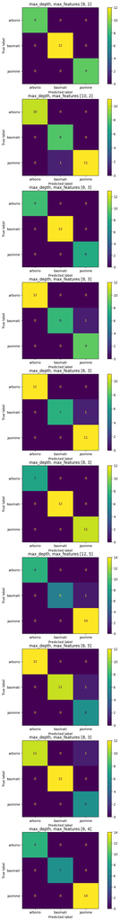

```python
print('Best params for each fold: ', best_params)
print('Accuracy scores for each fold: ' , accuracy_scores)

fig, axs = plt.subplots(10, figsize=(10, 50))

for x in range(10):
    cmd = metrics.ConfusionMatrixDisplay(confusion_matrix = confusion_matrices[x], display_labels = disp_labels)
    cmd.plot(ax=axs[x])
    title = 'max_depth, max_features ' + str(best_params[x])
    axs[x].title.set_text(title)

plt.show()
```

max_depth = 8, max_features = 3. Thhis combination shows up 3/10 times. With a mean accuracy score of 0.97777778

## MLP

This part has the same steps as KNNnestedCrossValidation. See it for comments if you like.

```python
mlp_model = MLPClassifier(max_iter=500, early_stopping=True, random_state=20)

hidden_layer_sizes = [(i,) for i in range(3,22)]
activation = ['logistic', 'relu']
solver = ['sgd', 'adam']
val_fr = [0.1, 0.5]

parameters = {
    'hidden_layer_sizes': hidden_layer_sizes,
    'activation': activation,
    'solver': solver,
    'validation_fraction': val_fr
}
```

```python
def MLPnestedCrossValidation():
    best_params = []
    accuracy_scores = []
    confusion_matrices = []

    for train_index, test_index in tqdm(cv_outer.split(features), total=10):

        train_features, test_features = features.iloc[train_index], features.iloc[test_index]
        train_labels, test_labels = labels.iloc[train_index], labels.iloc[test_index]

        mlp_cv = GridSearchCV(mlp_model, parameters, cv=cv_inner, return_train_score=False, n_jobs=-1)
        fit = mlp_cv.fit(train_features.values, train_labels)

        params = [mlp_cv.best_params_['hidden_layer_sizes'], mlp_cv.best_params_['activation'], mlp_cv.best_params_['solver'], mlp_cv.best_params_['validation_fraction']]
        best_params.append(params)
        best_model = fit.best_estimator_

        predictions = best_model.predict(test_features)
        accuracy_scores.append(accuracy_score(test_labels, predictions))

        confusion_matrices.append(metrics.confusion_matrix(test_labels, predictions, labels=best_model.classes_))

    return best_params, accuracy_scores, confusion_matrices, best_model.classes_
```

```python
best_params, accuracy_scores, confusion_matrices, disp_labels = MLPnestedCrossValidation()
```

[output not shown]

[output not shown]

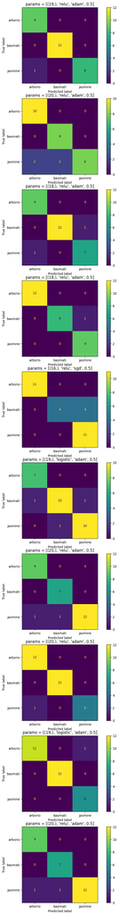

```python
print('Best params for each fold: ', best_params)
print('Accuracy scores for each fold: ' , accuracy_scores)

fig, axs = plt.subplots(10, figsize=(10, 50))

for x in range(10):
    cmd = metrics.ConfusionMatrixDisplay(confusion_matrix = confusion_matrices[x], display_labels = disp_labels)
    cmd.plot(ax=axs[x])
    title = 'params = ' + str(best_params[x])
    axs[x].title.set_text(title)

plt.show()
```

20 Relu adam 0.5 appears 4/10 times with mean accuracy score of 0.92

## Introduction

Write an introductory chapter for your report

#### Explain what is the purpose of this task?

The purpose is to reduce image data to numeric representation of the rice grains morphological and shape features that can be used to find the best model for classifying different types of rice grains. We use tree different types of rice: Arborio, Basmati and Jasmine. The idea for this task comes from a research paper  
İ. Çınar and M. Koklu. Identification of rice varieties using machine learning algorithms. Journal of Agricultural Sciences, 28(2):307–325, 2022. doi: 10.15832/ankutbd.862482.  
https://dergipark.org.tr/en/download/article-file/1513632

The numeric feature data is processed from images of rice grains. We got this images from Koklus website  
https://www.muratkoklu.com/datasets/vtdhnd09.php  
This website has 15 000 photos for five different rice types: 75 000 photos in total. In this project we randomly select 100 photo from Arborio, Basmati and Jasmine photo pools: 300 photos in total.

We make explore the data with boxplots, histograms, scatter plot and, PCA. Then we train k nearest neigbours, random forest and mlp models and search for best hyperparameters for them. We do this by repeated cross validation: 5folds and 3repetitions. Then we evaluated the models with nested cross validation.

## Discussion

Discuss you results

The models generalize well to these rice types that we used for training. The rice typed wwere clearly different in shape so much so that it could be seen with the naked eye. There are many rice types in the world and the models might not perform as well if they are added to the mix. The models will propably perform pretty well if we use it to predict the same type of rice we used to train it.

We got better result on KNN, same types of result for random forest and worse result for MLP than in the original paper. In the original paper they seemd to get the same type result in accuracy for all different methodds. We can't compare our result to the ones in the paper as we have less samples. We propably got better result for KNN because we have less rice types that are more distict to each other.

Application that can classify different species of could be used to identify eddible plants. This could be used by hobbyist. Mushromes are especially hard to identify. Many toxic mushromes look like non toxic ones. This could be a good future research field. To make mushroom collecting safer for people.